# Central African Republic Exports Time Series Analysis

Siddharth Das, Martin Topacio, Christine Li

3/16/24

# Course: STA 137 taught by Professor Xiucai Ding

## Data Preparation

```r
# Load data
load("finalproject.rdata")

# View data
head(finalPro_data)
```

|  | Country | Code | Year | GDP | Growth | CPI | Imports | Exports | Population |
| --- | --- | --- | --- | --- | --- | --- | --- | --- | --- |
| 1 | Central African Republic | CAF | 1960 | 112155599 | NA | NA | 34.18181 | 23.27272 | 1503508 |
| 2 | Central African Republic | CAF | 1961 | 123134584 | 4.9535538 | NA | 35.76159 | 26.49007 | 1529227 |
| 3 | Central African Republic | CAF | 1962 | 124482749 | -3.7138002 | NA | 37.70491 | 24.59017 | 1556661 |
| 4 | Central African Republic | CAF | 1963 | 129379098 | -0.7070108 | NA | 38.48581 | 25.23659 | 1585763 |
| 5 | Central African Republic | CAF | 1964 | 142025069 | 2.0803246 | NA | 40.80459 | 28.44827 | 1616516 |
| 6 | Central African Republic | CAF | 1965 | 150574816 | 0.9475787 | NA | 37.66938 | 27.10027 | 1648833 |

```r
# Access exports variable
exports <- finalPro_data$Exports

# Access year variable
year <- finalPro_data$Year

# Create time series object - might be necessary for later steps
exports <- ts(exports, start = year[1], end = year[length(year)])

# Print time series object
print(exports)
```

```
## Time Series:
## Start = 1960
## End = 2017
## Frequency = 1
##  [1] 23.27272 26.49007 24.59017 25.23659 28.44827 27.10027 28.35052 26.30273
##  [9] 34.31230 27.33466 31.93850 29.79923 24.93480 28.61804 27.73682 21.13035
## [17] 22.18687 25.20440 23.42032 22.43257 25.22155 24.38345 22.17775 24.14900
## [25] 23.39399 22.00852 18.18643 17.84414 17.74475 20.30389 17.06747 17.58667
## [33] 16.86570 17.09955 23.39941 22.22094 21.47039 26.88428 22.65689 19.22365
## [41] 20.37221 17.15725 15.96270 18.23600 13.99792 13.36275 14.31601 14.11533
## [49] 11.00366 10.68442 11.80725 11.51483 11.64916 14.45149 13.03009 12.61192
## [57] 12.72904 12.51809
```

## General procedure to build ARIMA

#### Step 1: Plot the data and identify any unusual observations.

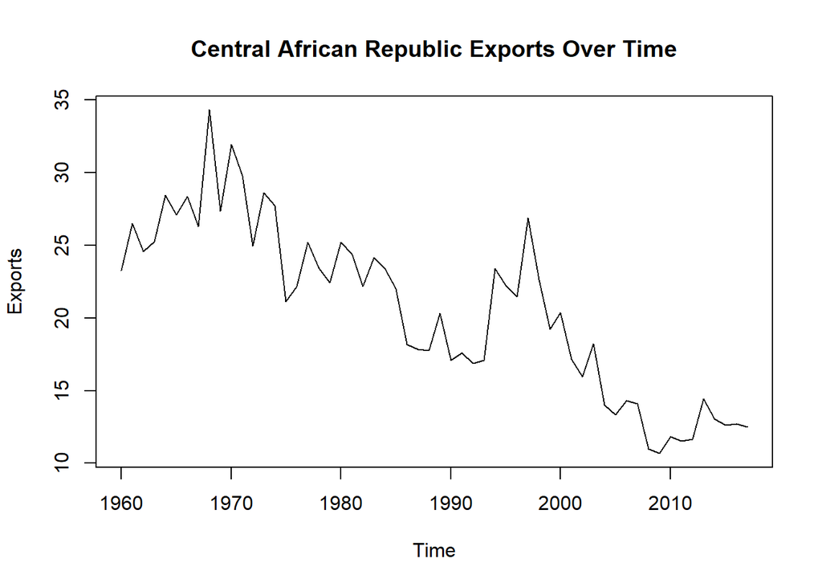

```r
# Utilize plot.ts() to visualize exports time series object
plot.ts(exports, xlab = "Time", ylab = "Exports", main = "Central African Republic Exports Over Time")
```

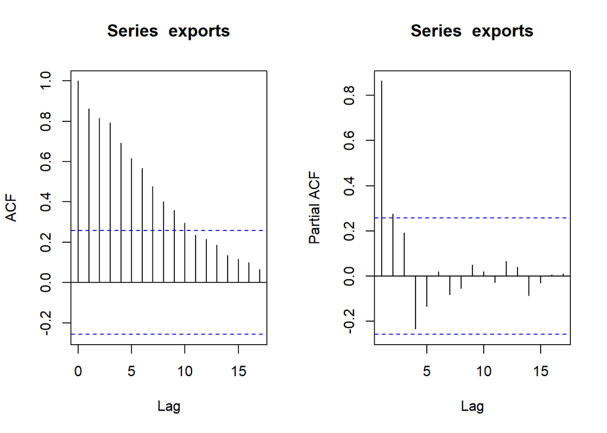

```r
# Prepare plot layout with 1 row and 2 columns
par(mfrow = c(1,2))

# Visualize ACF and PACF to determine if data is stationary
acf(exports)
pacf(exports)
```

ACF is decreasing in a linear trend. We can also see i stops lag at 1 showing non stationary. We now want to transform it into stationary form.

```r
# Load package for ADF & KPSS test
library(tseries)

#Conduct ADF to find if time series is stationary
adf.test(exports)
```

```
##
##  Augmented Dickey-Fuller Test
##
## data:  exports
## Dickey-Fuller = -3.1744, Lag order = 3, p-value = 0.1006
## alternative hypothesis: stationary
```

```r
# Confirm ADF test result with KPSS test
kpss.test(exports)
```

```
##
##  KPSS Test for Level Stationarity
##
## data:  exports
## KPSS Level = 1.2824, Truncation lag parameter = 3, p-value = 0.01
```

The Augmented Dickey-Fuller Test resulted in p-value = .1006, which is bigger than the assumed value of alpha = .05. Thus, Augmented Dickey-Fuller Test supports the conclusion that exports is a non-stationary time series.

Furthermore, The KPSS Test for Level Stationarity resulted in p-value = .01, which is less than the assumed value of alpha = .05. Hence, The KPSS Test for Level Stationarity also supports the conclusion that exports is a non-stationary time series.

```r
# Check for heteroskedasticity (non-constant variance)

# Checking through residual plots of linear regression
model1 = lm(exports ~ year)
summary(model1)
```

```
##
## Call:
## lm(formula = exports ~ year)
##
## Residuals:
##     Min      1Q  Median      3Q     Max
## -6.0805 -2.2845 -0.3226  1.6844  8.8177
##
## Coefficients:
##              Estimate Std. Error t value Pr(>|t|)
## (Intercept) 627.23851   46.54819   13.47   <2e-16 ***
## year         -0.30504    0.02341  -13.03   <2e-16 ***
## ---
## Signif. codes:  0 '***' 0.001 '**' 0.01 '*' 0.05 '.' 0.1 ' ' 1
##
## Residual standard error: 2.984 on 56 degrees of freedom
## Multiple R-squared:  0.752,  Adjusted R-squared:  0.7476
## F-statistic: 169.8 on 1 and 56 DF,  p-value: < 2.2e-16
```

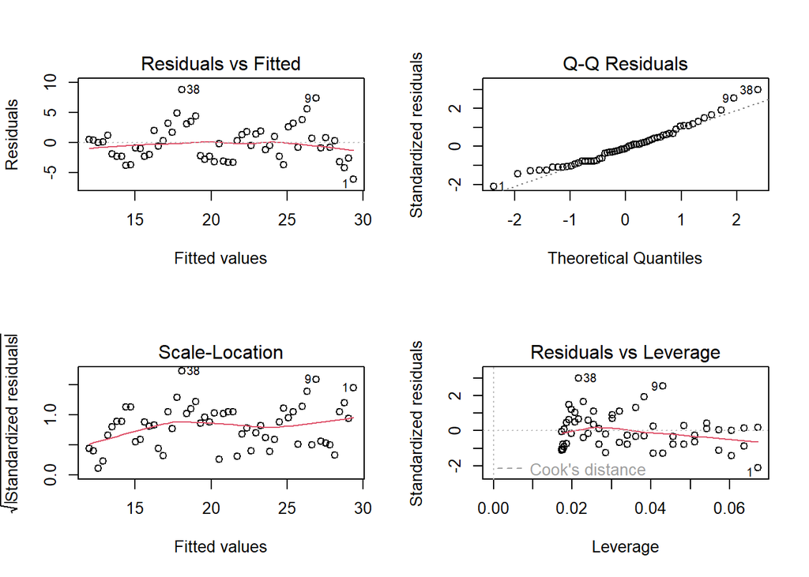

```r
par(mfrow=c(2,2))
plot(model1)
```

```r
#We don't need to see through linear regression, Arima to check for heteroskedasticity. We can check through the plots you created.
# If there is absolutely no heteroskedasticity, you should see a completely random, equal distribution of points throughout the range of X axis and a flat red line.Ours is not neccasrily flat hence we can claim that there's heteroskedasticity. Our data points are also very spread out.
```

#### Step 2: If necessary, transform the data (using a Box-Cox transformation) to stabilize the variance.

We will try Box-Cox, log, and square root transformations to find the optimal method for stabilized variance.

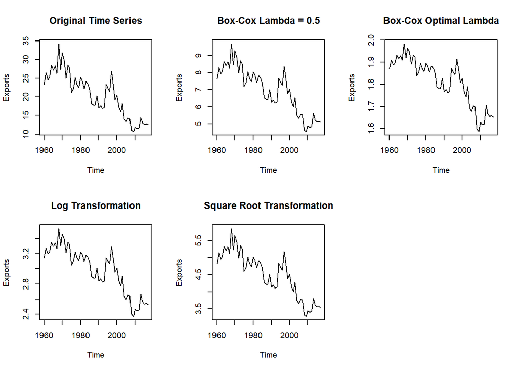

```r
# Cite Source: https://datascienceplus.com/time-series-analysis-in-r-part-2-time-series-transformations/

# Load the forecast package for Box-Cox transformation
library("forecast")

# Prepare 2 x 3 grid layout to display 5 plots
par(mfrow = c(2, 3))

# Plot original times series
plot.ts(exports, xlab = "Time", ylab = "Exports", main = "Original Time Series")

# Box-Cox transformation with lambda = 0.5
exports_box_cox_half <- BoxCox(exports, lambda = 0.5)
plot.ts(exports_box_cox_half, xlab = "Time", ylab = "Exports", main = "Box-Cox Lambda = 0.5")

# Box-Cox transformation with optimal lambda
lambda <- BoxCox.lambda(exports)
exports_box_cox <- BoxCox(exports, lambda = lambda)
plot.ts(exports_box_cox, xlab = "Time", ylab = "Exports", main = "Box-Cox Optimal Lambda")

# Log transformation
exports_log <- log(exports)
plot.ts(exports_log, xlab = "Time", ylab = "Exports", main = "Log Transformation")

# Square root transformation
exports_sqrt <- sqrt(exports)
model1 = lm(exports ~ year)
plot.ts(exports_sqrt, xlab = "Time", ylab = "Exports", main = "Square Root Transformation")
```

```r
# Print lambda value for Box-Cox transformation with optimal lambda
print(paste("The lambda value for Box-Cox transformation with optimal lambda is", lambda))
```

```
## [1] "The lambda value for Box-Cox transformation with optimal lambda is -0.365088433219557"
```

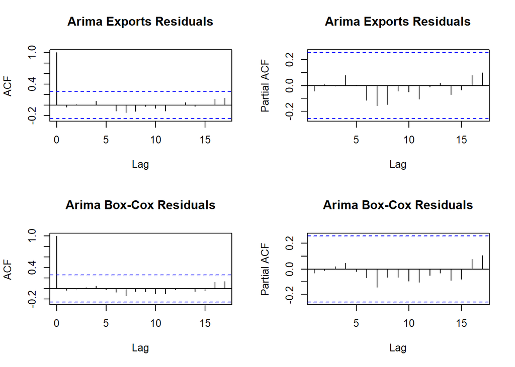

```r
# Prepare 2 x 2 grid layout to display 4 plots
par(mfrow = c(2, 2))

# Determine and fit ARIMA model to exports
exports_arima_model <- auto.arima(exports)
# Extract residuals from the ARIMA model
residuals <- residuals(exports_arima_model)
# Plot ACF of residuals
acf(residuals, main = "Arima Exports Residuals")
# Plot PACF of residuals
pacf(residuals, main = "Arima Exports Residuals")

# Determine and fit ARIMA model to exports
exports_box_cox_arima_model <- auto.arima(exports_box_cox)
# Extract residuals from the ARIMA model
residuals <- residuals(exports_box_cox_arima_model)
# Plot ACF of residuals
acf(residuals, main = "Arima Box-Cox Residuals")
# Plot PACF of residuals
pacf(residuals, main = "Arima Box-Cox Residuals")
```

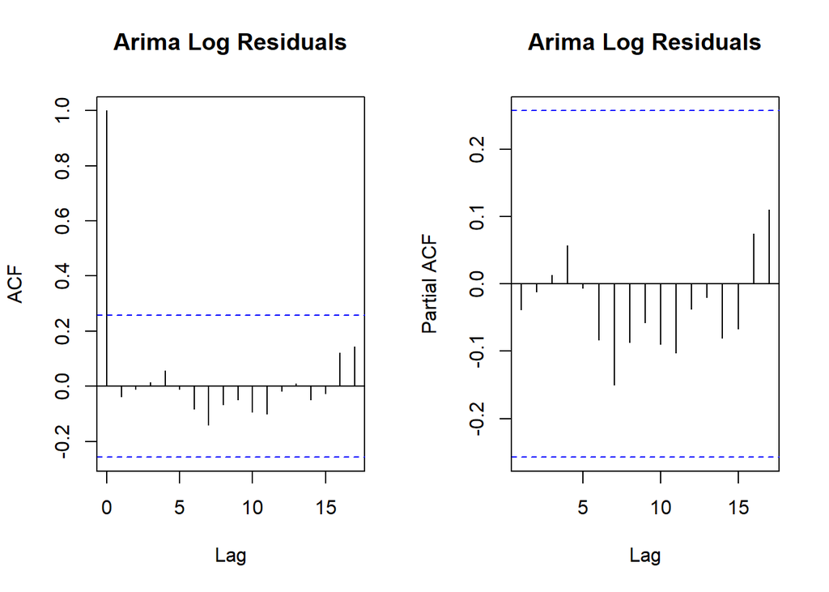

```r
# Prepare 1 x 2 grid layout to display 2 plots
par(mfrow = c(1, 2))

# Determine and fit ARIMA model to exports
exports_log_arima_model <- auto.arima(exports_log)
# Extract residuals from the ARIMA model
residuals <- residuals(exports_log_arima_model)
# Plot ACF of residuals
acf(residuals, main = "Arima Log Residuals")
# Plot PACF of residuals
pacf(residuals, main = "Arima Log Residuals")
```

```r
summary(exports_arima_model)
```

```
## Series: exports
## ARIMA(2,1,2)
##
## Coefficients:
##           ar1      ar2     ma1     ma2
##       -0.6741  -0.7142  0.2468  0.4831
## s.e.   0.1821   0.2037  0.2531  0.2576
##
## sigma^2 = 6.416:  log likelihood = -132.1
## AIC=274.2   AICc=275.37   BIC=284.41
##
## Training set error measures:
##                      ME     RMSE      MAE       MPE     MAPE      MASE
## Training set -0.2645835 2.421275 1.821659 -2.327502 8.929045 0.8318532
##                     ACF1
## Training set -0.04168949
```

```r
summary(exports_box_cox_arima_model)
```

```
## Series: exports_box_cox
## ARIMA(2,1,2)
##
## Coefficients:
##           ar1      ar2     ma1     ma2
##       -0.6941  -0.8157  0.4403  0.5629
## s.e.   0.1435   0.1821  0.2033  0.2948
##
## sigma^2 = 0.001526:  log likelihood = 105.72
## AIC=-201.44   AICc=-200.26   BIC=-191.22
##
## Training set error measures:
##                        ME       RMSE        MAE        MPE     MAPE      MASE
## Training set -0.004862574 0.03733788 0.02794781 -0.3031653 1.552617 0.8332397
##                     ACF1
## Training set -0.03023168
```

```r
summary(exports_log_arima_model)
```

```
## Series: exports_log
## ARIMA(2,1,2)
##
## Coefficients:
##           ar1      ar2     ma1     ma2
##       -0.6924  -0.8006  0.3985  0.5571
## s.e.   0.1455   0.1879  0.2067  0.2985
##
## sigma^2 = 0.01354:  log likelihood = 43.49
## AIC=-76.98   AICc=-75.81   BIC=-66.77
##
## Training set error measures:
##                       ME      RMSE        MAE        MPE     MAPE      MASE
## Training set -0.01395682 0.1112344 0.08445742 -0.5805899 2.849815 0.8352866
##                     ACF1
## Training set -0.03795421
```

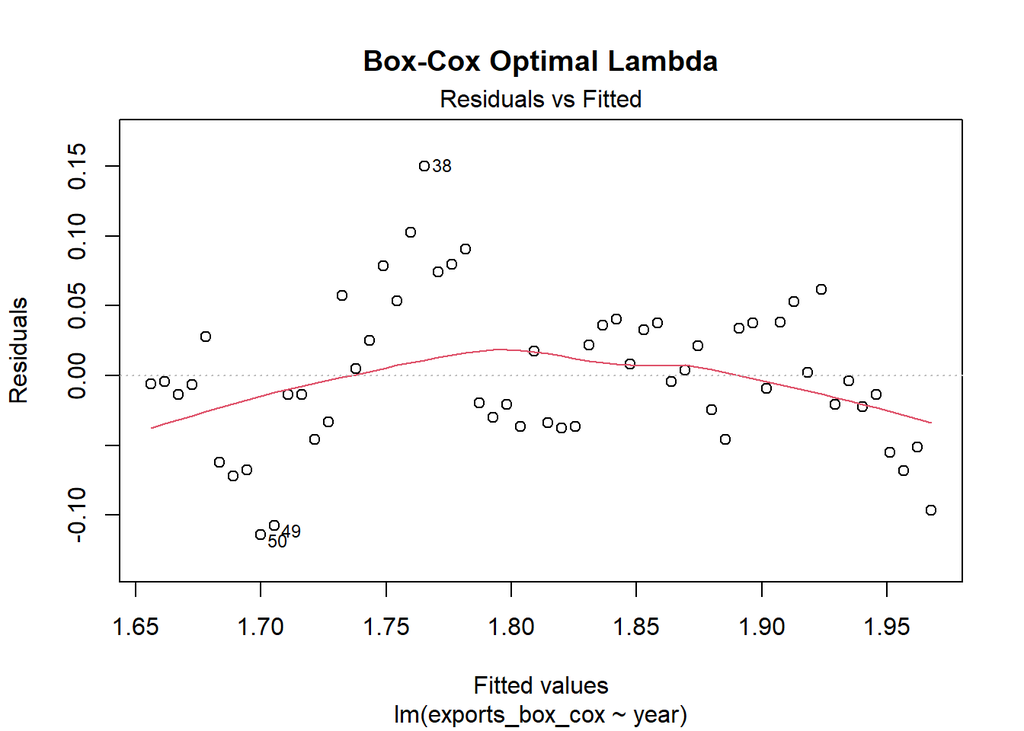

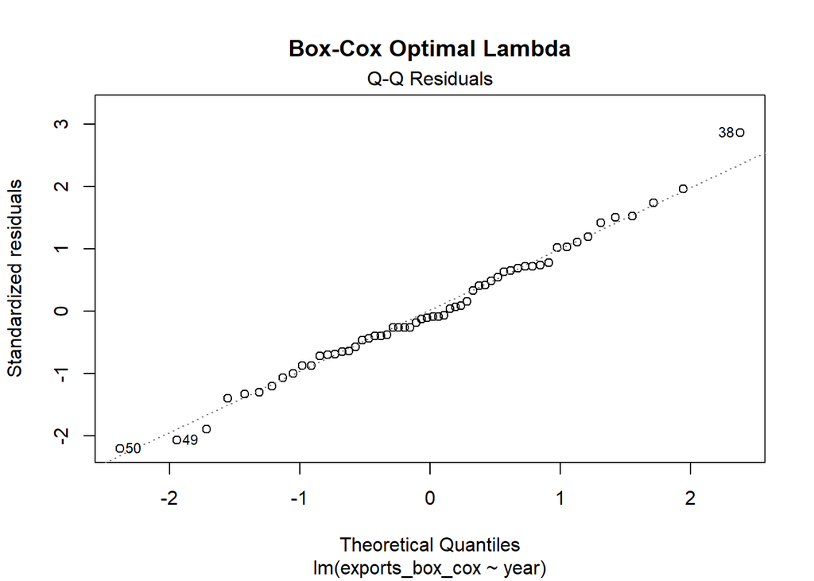

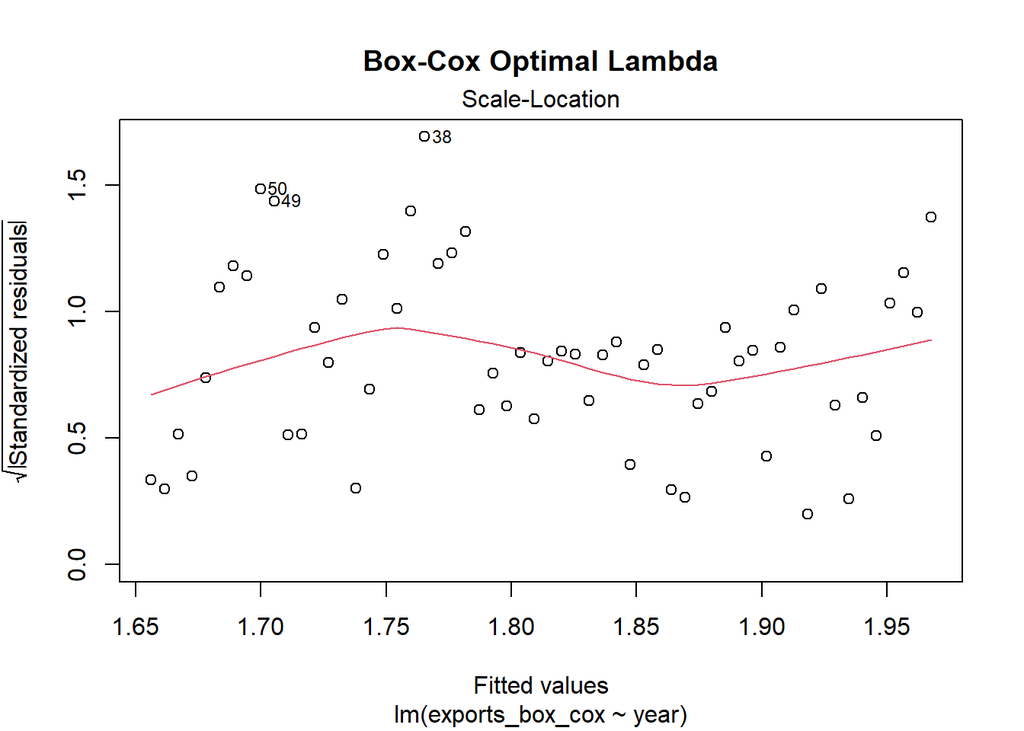

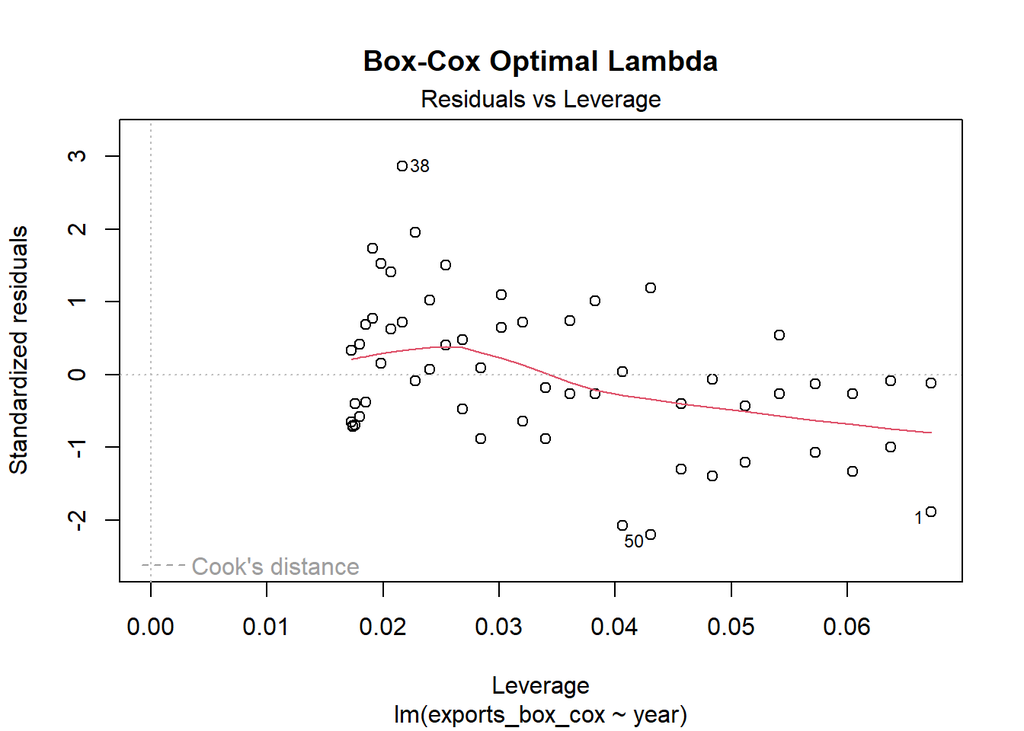

```r
# Box-Cox transformation with optimal lambda
exports_box_cox_model = lm(exports_box_cox ~ year)
plot(exports_box_cox_model,main = "Box-Cox Optimal Lambda")
```

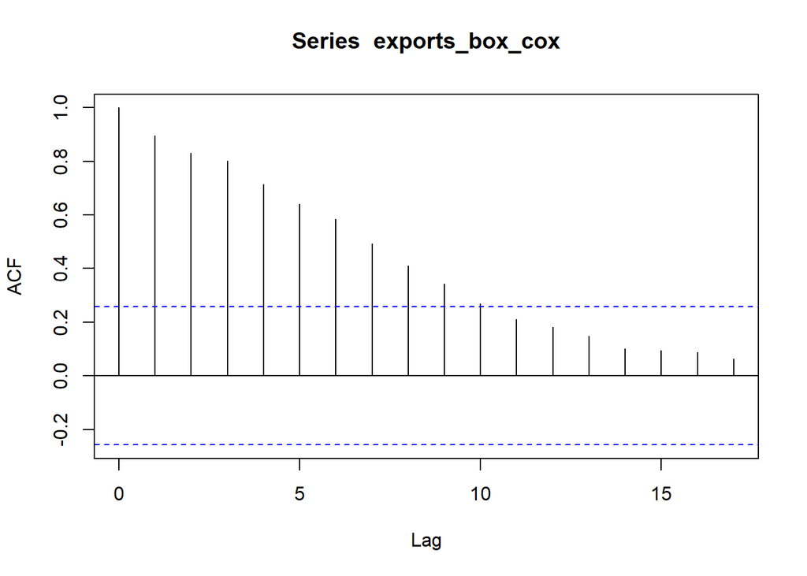

```r
acf(exports_box_cox)
```

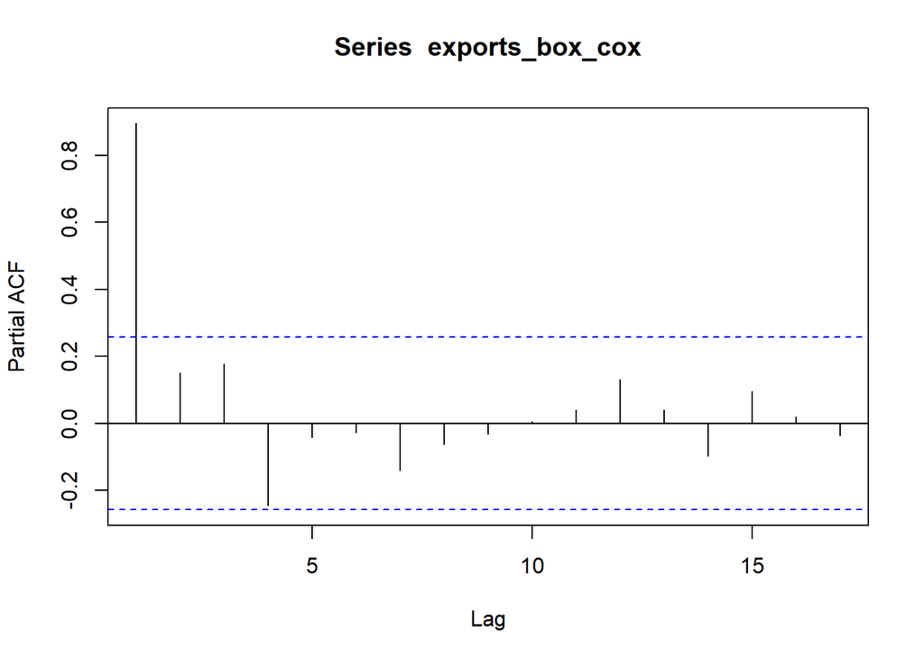

```r
pacf(exports_box_cox)
```

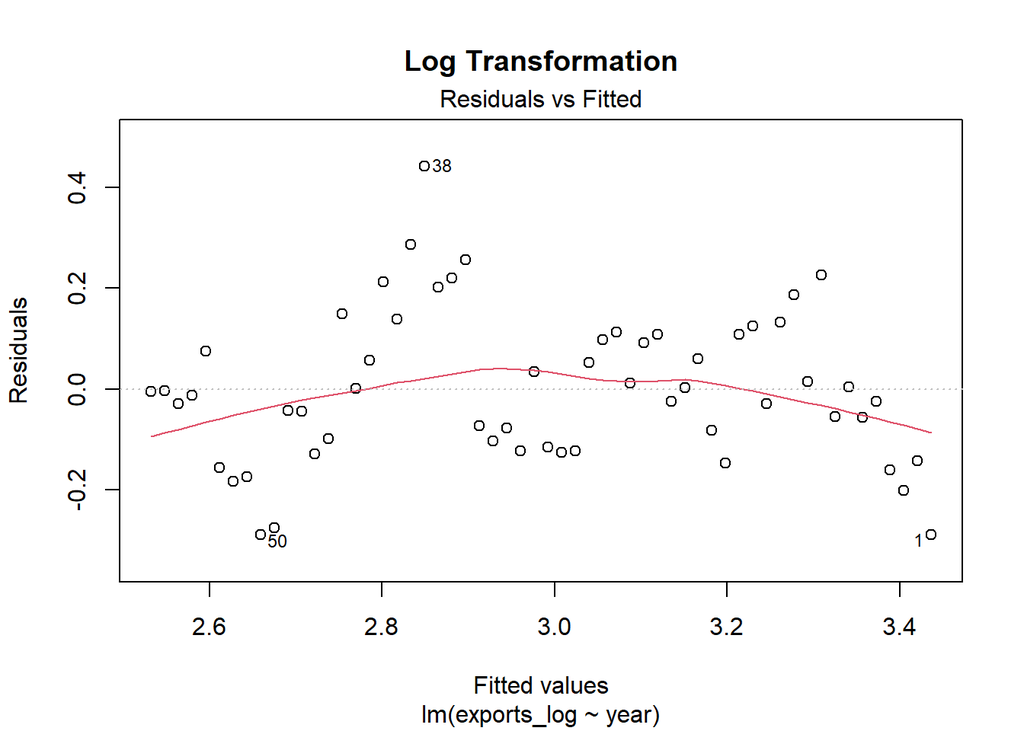

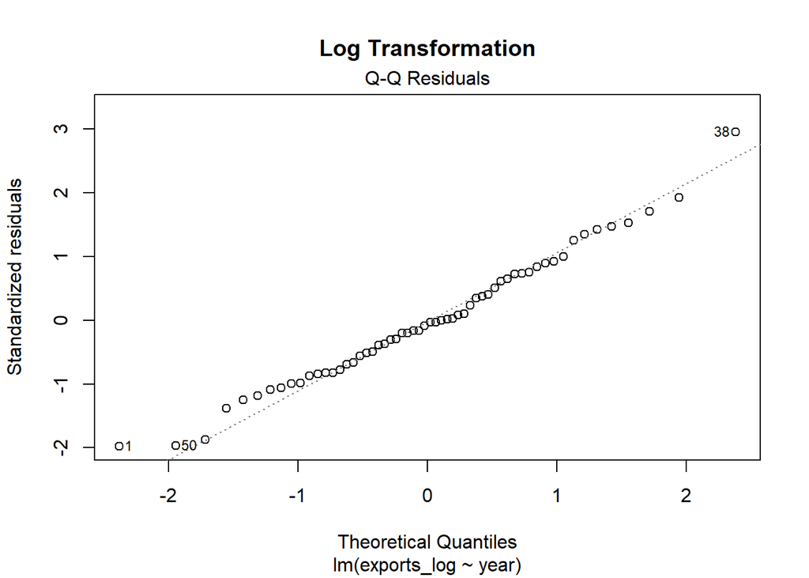

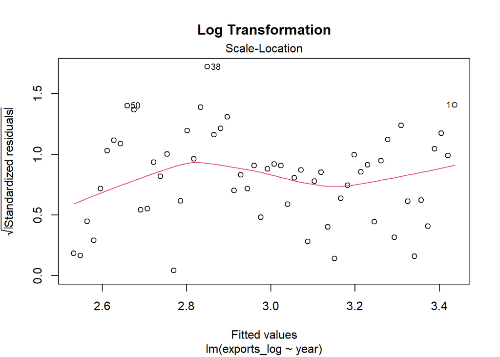

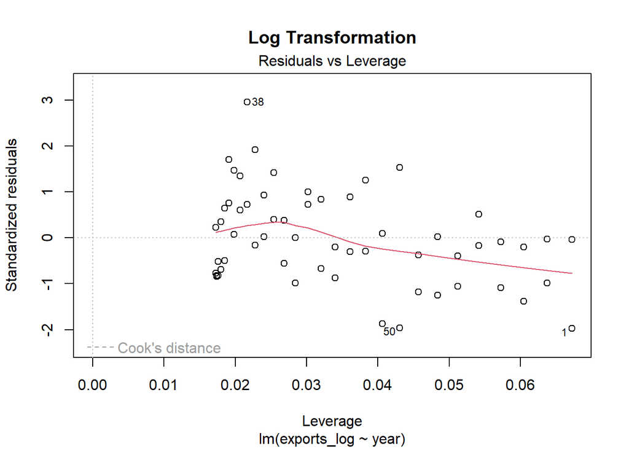

```r
# Log transformation
exports_log_model = lm(exports_log ~ year)
plot(exports_log_model,main = "Log Transformation")
```

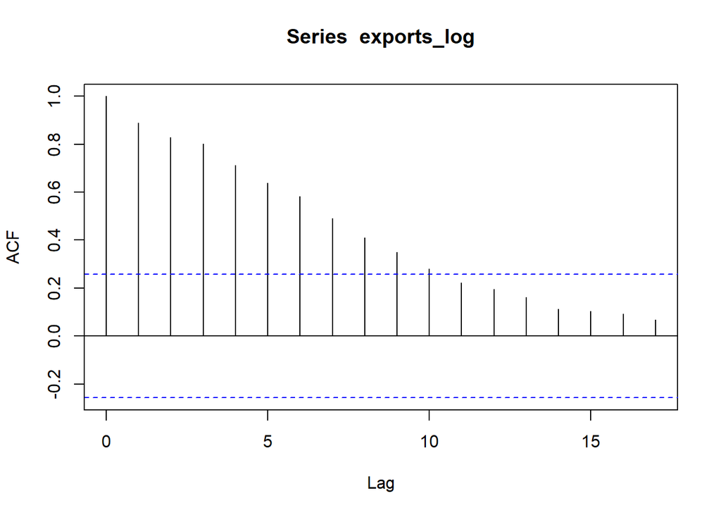

```r
acf(exports_log)
```

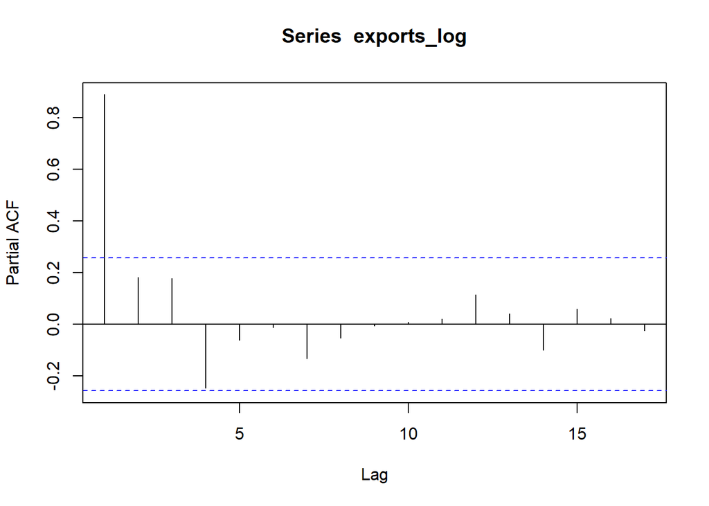

```r
pacf(exports_log)
```

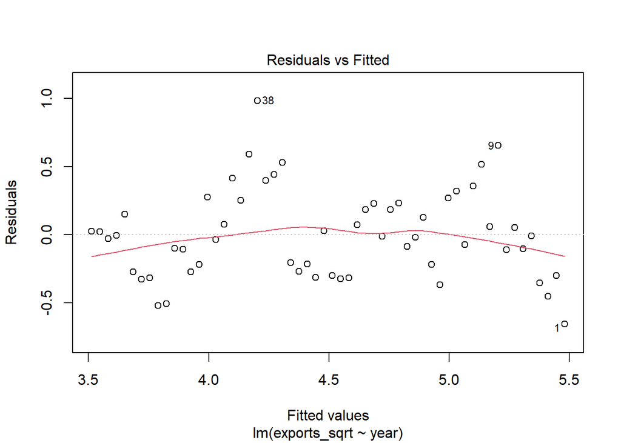

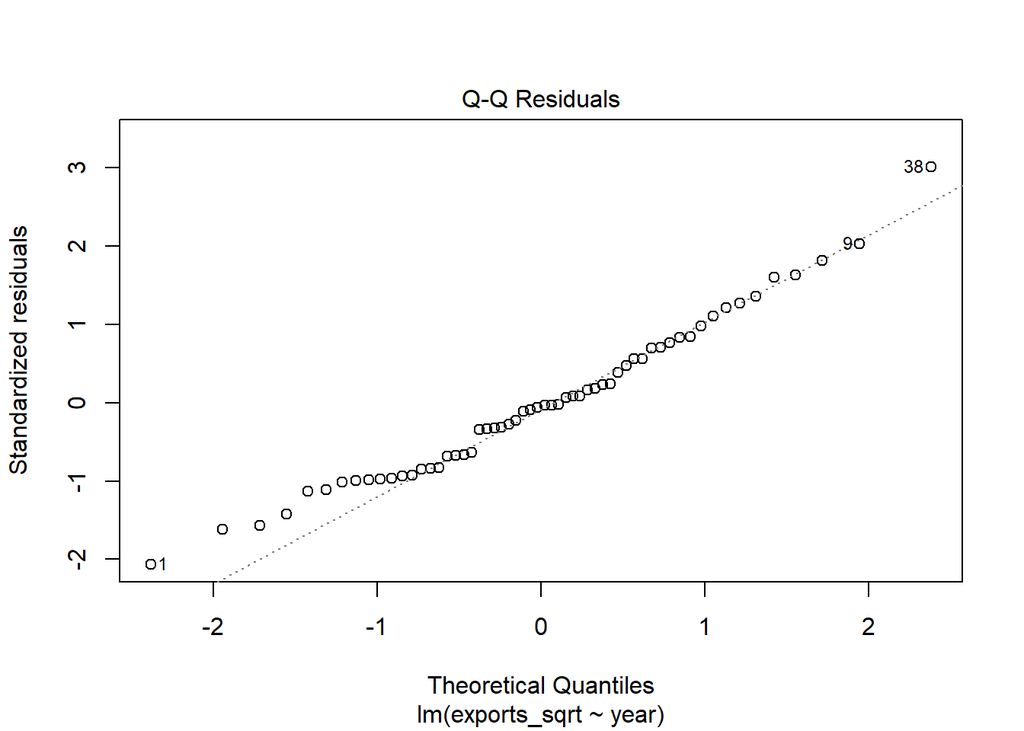

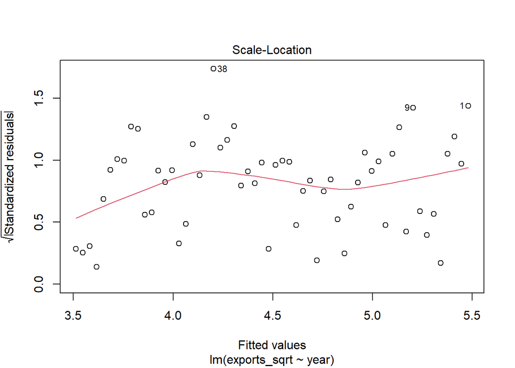

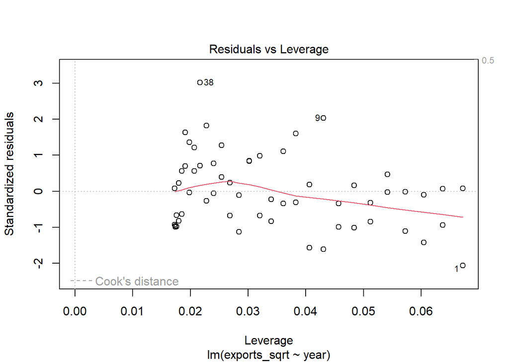

```r
# Square root transformation
exports_sqrt_model = lm(exports_sqrt ~ year)
plot(exports_sqrt_model)
```

HOW DO WE DETERMINE WHICH METHOD WAS MOST EFFEECTIVE FOR STABILIZING VARIANCE? Methods for choosing the power λ are available (see Johnson and Wichern, 1992, §4.7) but we do not pursue them here. Often, transformations are also used to improve the approximation to normality or to improve linearity in predicting the value of one series from another. I just picked Box-Cox bc of smallest range of values but i don’t think that is the correct reasoning. Box Cox transformation can improve the accuracy of predictions made using linear regression Box-Cox Transformation Select the lambda value that Minitab uses to transform the data: No transformation: Use your original response data. Optimal λ: This option is not available if the batch is a random factor. Use the optimal lambda, which should produce the best fitting transformation. Minitab rounds the optimal lambda to 0.5 or the nearest integer. λ = 0 (natural log): Use the natural log of your data. λ = 0.5 (square root): Use the square root of your data. λ: Use a specified value for lambda. Other common transformations are square (λ = 2), inverse square root (λ = – 0.5), and inverse (λ = – 1). Usually, you should not use a value outside the range of -2 and 2.

SID

The Box-Cox transformation utilizing the optimal value of lambda (-0.3650884) appears to be most effective for stabilizing the variance. However, the time series still appears to have a decreasing trend over time, so we will take the first differences of the Box-Cox optimal lambda time series until the data becomes stationary.

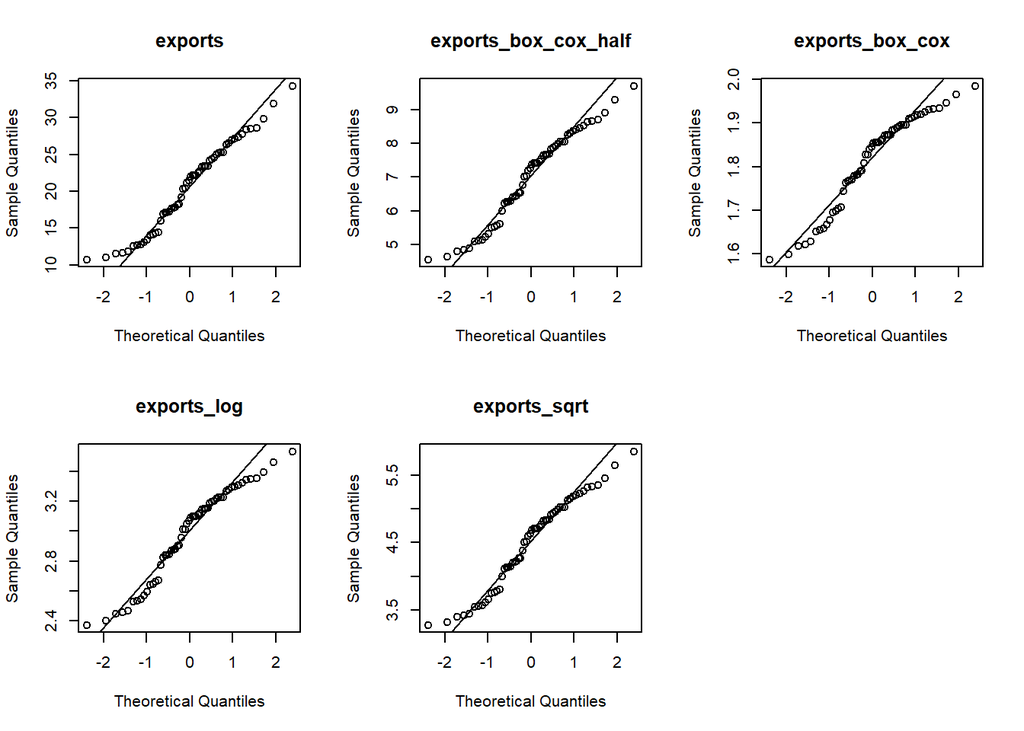

```r
# Trying to figure out which transformation results in most stable variance but idk how to determine most stable variance
# we would want the data that is the most normal to show stable variance
#I read that these are the conditions for using the multiple regression model:
  #the residuals of the model are nearly normal,
  #the variability of the residuals is nearly constant
  #the residuals are independent, and
  #each variable is linearly related to the outcome.

par(mfrow = c(2, 3))
qqnorm(exports, main = 'exports')
qqline(exports)
qqnorm(exports_box_cox_half,main = 'exports_box_cox_half')
qqline(exports_box_cox_half)
qqnorm(exports_box_cox,main='exports_box_cox')
qqline(exports_box_cox)
qqnorm(exports_log,main = 'exports_log')
qqline(exports_log)
qqnorm(exports_sqrt,main='exports_sqrt')
qqline(exports_sqrt)
```

#### Step 3: If the data are non-stationary, take first differences of the data until the data are stationary.

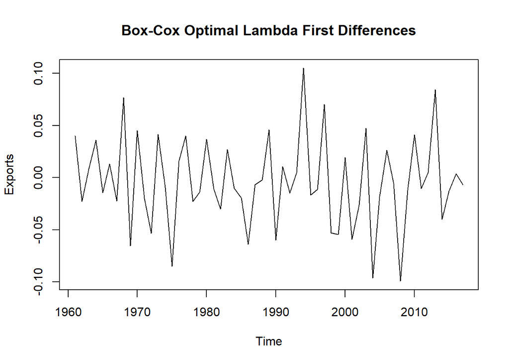

```r
# Cite Source: https://datascienceplus.com/time-series-analysis-in-r-part-2-time-series-transformations/

# Compute first differences of time series utilizing Box-Cox transformation with optimal lambda
exports_diff <- diff(exports_box_cox)

# Plot first differences
plot.ts(exports_diff, xlab = "Time", ylab = "Exports", main = "Box-Cox Optimal Lambda First Differences")
```

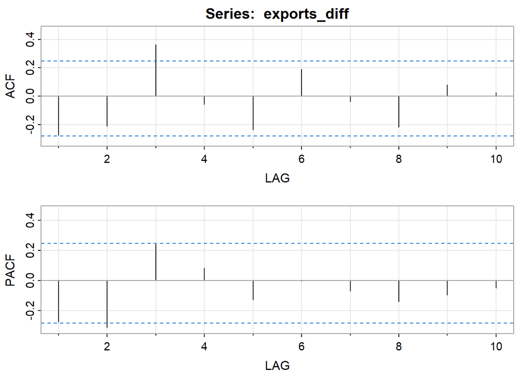

```
##       [,1]  [,2] [,3]  [,4]  [,5] [,6]  [,7]  [,8]  [,9] [,10]
## ACF  -0.28 -0.21 0.36 -0.06 -0.24 0.19 -0.04 -0.22  0.08  0.02
## PACF -0.28 -0.31 0.24  0.08 -0.13 0.00 -0.07 -0.14 -0.10 -0.05
```

```r
library(astsa)
acf2(exports_diff)
```

```r
#The following ACF shows exponential decay which which hence indicate sa stationary time series. When it is expoential decay it should look like waves. It;s AR(2) model where lag two the line exceeds the blue line.The ACF shows MA(3) where the third lag reches pass the blue line. We can check of ARIMA(2,1,0),ARIMA(0,1,3)
# We can also check for stationary of diff through KPSS test like previous
kpss.test(exports_diff)
```

```
##
##  KPSS Test for Level Stationarity
##
## data:  exports_diff
## KPSS Level = 0.1058, Truncation lag parameter = 3, p-value = 0.1
```

```r
#The pvalue is .1 which is bigger than alpha .05 hence claim that it is stationary after the first Diff.
```

Mean appears to be constant and close to zero. Variance appears to be relatively stable across time. Decreasing trend appears to be removed by taking first differences of the Box-Cox optimal lambda time series. Time series appears to be stationary. Now we can proceed with examining the ACF and PACF of the time series, and initiate the process of determining the best model

#### Step 4: Examine the ACF/PACF: MA or AR for the difference?

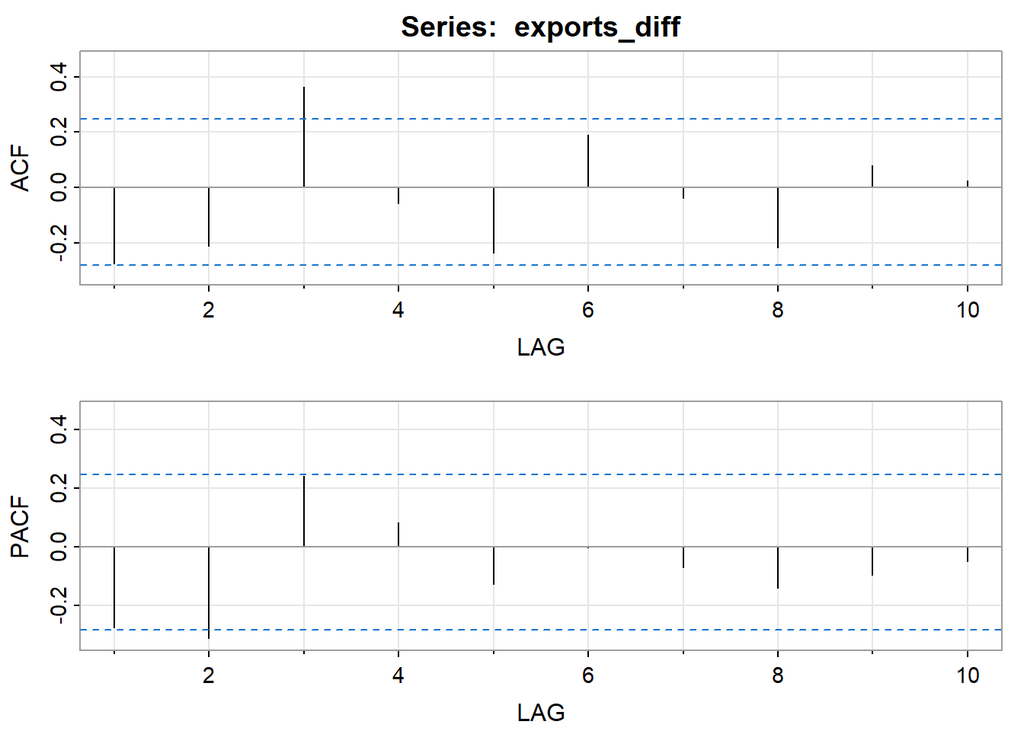

```
##       [,1]  [,2] [,3]  [,4]  [,5] [,6]  [,7]  [,8]  [,9] [,10]
## ACF  -0.28 -0.21 0.36 -0.06 -0.24 0.19 -0.04 -0.22  0.08  0.02
## PACF -0.28 -0.31 0.24  0.08 -0.13 0.00 -0.07 -0.14 -0.10 -0.05
```

```r
library(astsa)
acf2(exports_diff)
```

```r
#The following ACF shows exponential decay which which hence indicate sa stationary time series. When it is expoential decay it should look like waves. It's AR(2) model where lag two the line exceeds the blue line.The ACF shows MA(3) where the third lag reches pass the blue line. We can check of ARIMA(2,1,0),ARIMA(0,1,3)
```

#### Step 5: Try your chosen model(s) and use the AIC/BIC to search for a better model.

AR(1)

```r
# Fit AR(1) model to the data
ar1_model <- arima(exports_diff, order = c(1, 0, 0))

# Summary of the AR(1) model
summary(ar1_model)
```

```
##
## Call:
## arima(x = exports_diff, order = c(1, 0, 0))
##
## Coefficients:
##           ar1  intercept
##       -0.2757    -0.0040
## s.e.   0.1272     0.0043
##
## sigma^2 estimated as 0.001689:  log likelihood = 101.01,  aic = -196.02
##
## Training set error measures:
##                       ME       RMSE        MAE      MPE     MAPE      MASE
## Training set 0.000183412 0.04110055 0.03053935 72.92011 92.16427 0.5261981
##                     ACF1
## Training set -0.08542746
```

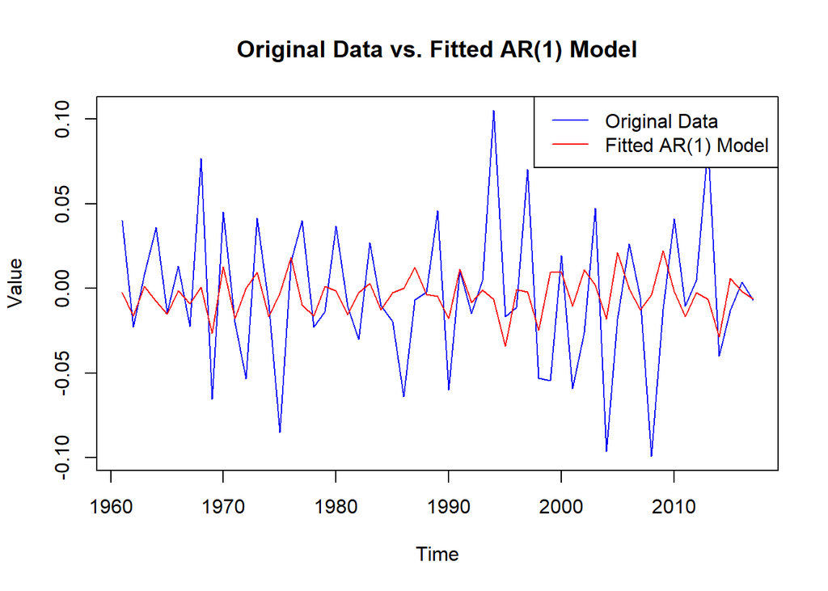

```r
# Plot the original data and the fitted values
plot(exports_diff, type = "l", col = "blue", xlab = "Time", ylab = "Value", main = "Original Data vs. Fitted AR(1) Model")
lines(fitted(ar1_model), col = "red")

# Add a legend
legend("topright", legend = c("Original Data", "Fitted AR(1) Model"), col = c("blue", "red"), lty = 1)
```

AR(2)

```r
# Fit AR(2) model to the data
ar2_model <- arima(exports_diff, order = c(2, 0, 0))

# Summary of the AR(2) model
summary(ar2_model)
```

```
##
## Call:
## arima(x = exports_diff, order = c(2, 0, 0))
##
## Coefficients:
##           ar1      ar2  intercept
##       -0.3607  -0.3062    -0.0041
## s.e.   0.1261   0.1244     0.0031
##
## sigma^2 estimated as 0.001523:  log likelihood = 103.86,  aic = -199.73
##
## Training set error measures:
##                       ME       RMSE        MAE      MPE     MAPE     MASE
## Training set 0.000290828 0.03902515 0.02929537 81.45007 117.2612 0.504764
##                    ACF1
## Training set 0.07139439
```

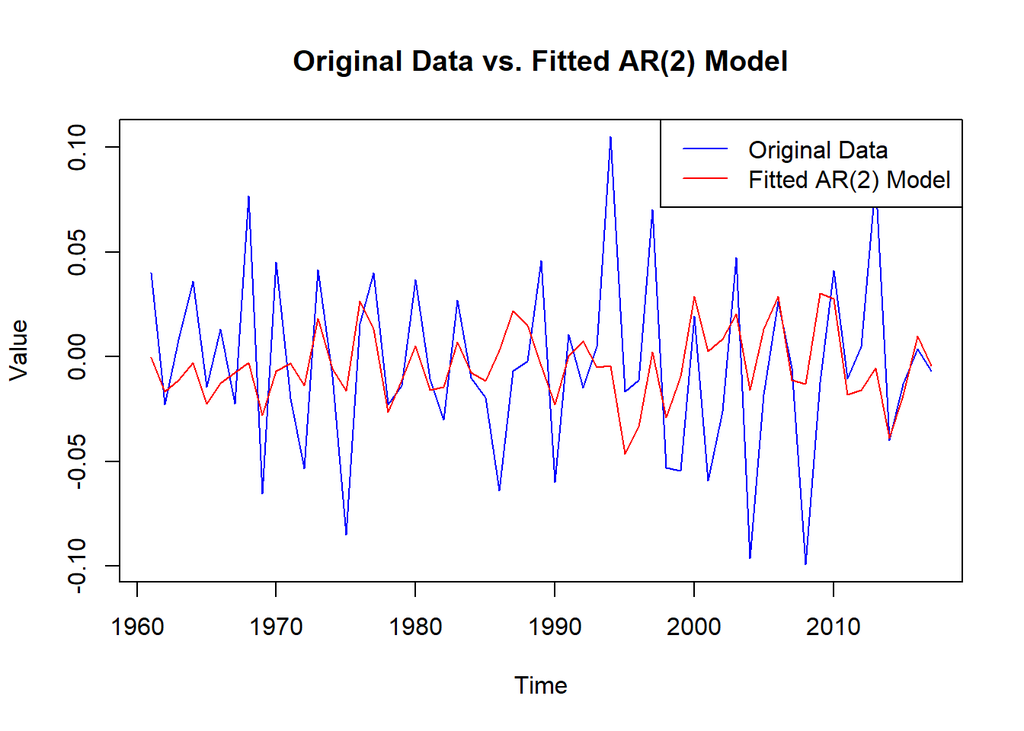

```r
# Plot the original data and the fitted values
plot(exports_diff, type = "l", col = "blue", xlab = "Time", ylab = "Value", main = "Original Data vs. Fitted AR(2) Model")
lines(fitted(ar2_model), col = "red")

# Add a legend
legend("topright", legend = c("Original Data", "Fitted AR(2) Model"), col = c("blue", "red"), lty = 1)
```

MA(1)

```r
# Fit MA(1) model to the data
ma1_model <- arima(exports_diff, order = c(0, 0, 1))

# Summary of the MA(1) model
summary(ma1_model)
```

```
##
## Call:
## arima(x = exports_diff, order = c(0, 0, 1))
##
## Coefficients:
##           ma1  intercept
##       -0.3522    -0.0041
## s.e.   0.1178     0.0035
##
## sigma^2 estimated as 0.001629:  log likelihood = 102.02,  aic = -198.03
##
## Training set error measures:
##                        ME       RMSE        MAE      MPE     MAPE      MASE
## Training set 0.0002995547 0.04036158 0.02956057 77.24906 95.98957 0.5093335
##                     ACF1
## Training set 0.003305956
```

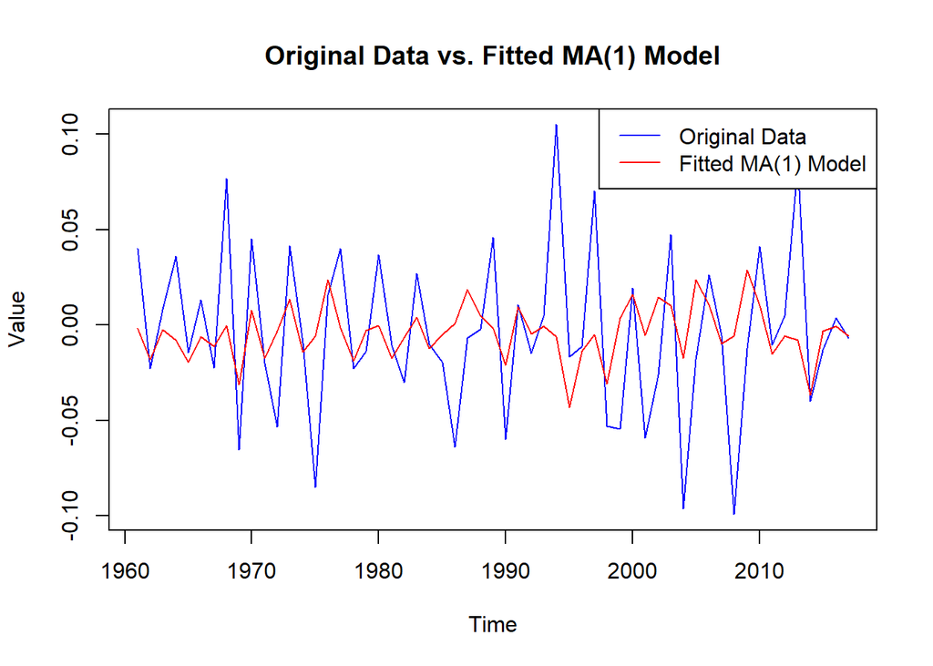

```r
# Plot the original data and the fitted values
plot(exports_diff, type = "l", col = "blue", xlab = "Time", ylab = "Value", main = "Original Data vs. Fitted MA(1) Model")
lines(fitted(ma1_model), col = "red")

# Add a legend
legend("topright", legend = c("Original Data", "Fitted MA(1) Model"), col = c("blue", "red"), lty = 1)
```

MA(2)

```r
# Fit MA(2) model to the data
ma2_model <- arima(exports_diff, order = c(0, 0, 2))

# Summary of the MA(2) model
summary(ma2_model)
```

```
##
## Call:
## arima(x = exports_diff, order = c(0, 0, 2))
##
## Coefficients:
##           ma1      ma2  intercept
##       -0.3265  -0.0397    -0.0041
## s.e.   0.2079   0.2651     0.0034
##
## sigma^2 estimated as 0.001629:  log likelihood = 102.03,  aic = -196.06
##
## Training set error measures:
##                        ME       RMSE        MAE      MPE     MAPE      MASE
## Training set 0.0003218025 0.04035607 0.02950569 81.37784 95.57609 0.5083879
##                     ACF1
## Training set -0.01118327
```

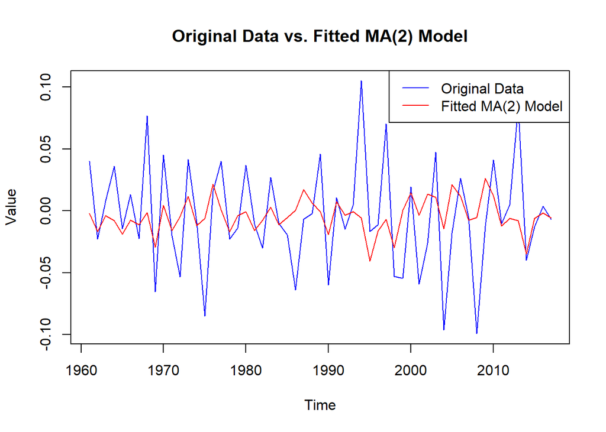

```r
# Plot the original data and the fitted values
plot(exports_diff, type = "l", col = "blue", xlab = "Time", ylab = "Value", main = "Original Data vs. Fitted MA(2) Model")
lines(fitted(ma2_model), col = "red")

# Add a legend
legend("topright", legend = c("Original Data", "Fitted MA(2) Model"), col = c("blue", "red"), lty = 1)
```

MA(3)

```r
# Fit MA(3) model to the data
ma3_model <- arima(exports_diff, order = c(0, 0, 3))

# Summary of the MA(3) model
summary(ma3_model)
```

```
##
## Call:
## arima(x = exports_diff, order = c(0, 0, 3))
##
## Coefficients:
##           ma1      ma2     ma3  intercept
##       -0.2844  -0.0685  0.2877    -0.0040
## s.e.   0.1235   0.1371  0.1223     0.0047
##
## sigma^2 estimated as 0.001487:  log likelihood = 104.52,  aic = -199.03
##
## Training set error measures:
##                         ME       RMSE        MAE      MPE    MAPE      MASE
## Training set -2.733548e-05 0.03855893 0.02995641 64.57064 120.273 0.5161539
##                     ACF1
## Training set -0.02586834
```

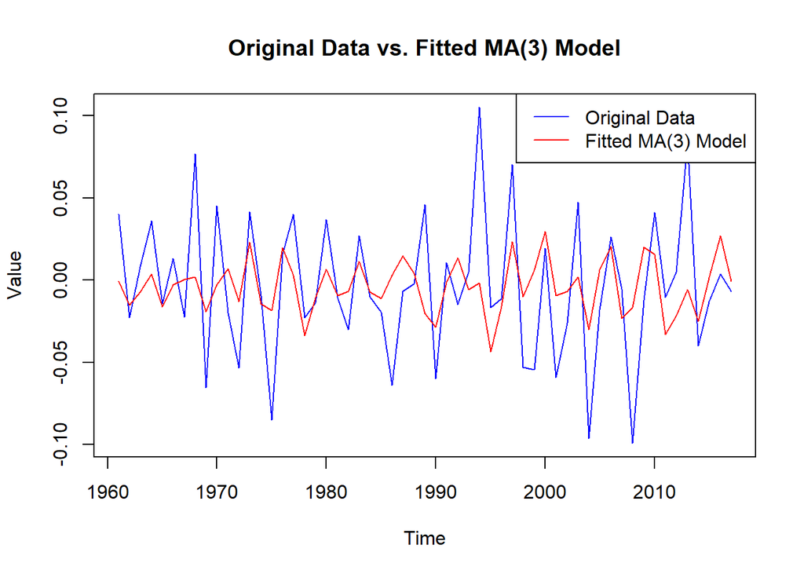

```r
# Plot the original data and the fitted values
plot(exports_diff, type = "l", col = "blue", xlab = "Time", ylab = "Value", main = "Original Data vs. Fitted MA(3) Model")
lines(fitted(ma3_model), col = "red")

# Add a legend
legend("topright", legend = c("Original Data", "Fitted MA(3) Model"), col = c("blue", "red"), lty = 1)
```

AIC/BIC

```r
# Compute AIC and BIC values for each model
aic_values <- c(AIC(ar1_model), AIC(ma1_model), AIC(ar2_model), AIC(ma2_model), AIC(ma3_model))
bic_values <- c(BIC(ar1_model), BIC(ma1_model), BIC(ar2_model), BIC(ma2_model), BIC(ma3_model))

# Create a data frame to organize the results
results <- data.frame(Model = c("AR(1)", "MA(1)", "AR(2)", "MA(2)", "MA"), AIC = aic_values, BIC = bic_values)

# Calculate the absolute difference between AIC and BIC
results$Abs_Diff <- abs(results$AIC - results$BIC)

# Print the results
print(results)
```

```
##   Model       AIC       BIC  Abs_Diff
## 1 AR(1) -196.0196 -189.8905  6.129154
## 2 MA(1) -198.0345 -191.9054  6.129154
## 3 AR(2) -199.7294 -191.5572  8.172205
## 4 MA(2) -196.0566 -187.8844  8.172205
## 5    MA -199.0316 -188.8164 10.215256
```

Using auto.arima() function

```r
# Fit an ARIMA model automatically
auto_arima_model <- auto.arima(exports_diff)

# Summary of the automatically selected ARIMA model
summary(auto_arima_model)
```

```
## Series: exports_diff
## ARIMA(2,0,2) with zero mean
##
## Coefficients:
##           ar1      ar2     ma1     ma2
##       -0.6941  -0.8157  0.4403  0.5629
## s.e.   0.1435   0.1821  0.2033  0.2948
##
## sigma^2 = 0.001526:  log likelihood = 105.72
## AIC=-201.44   AICc=-200.26   BIC=-191.22
##
## Training set error measures:
##                       ME       RMSE        MAE      MPE     MAPE      MASE
## Training set -0.00498072 0.03766316 0.02840531 44.86921 113.7187 0.4894282
##                     ACF1
## Training set -0.03374676
```

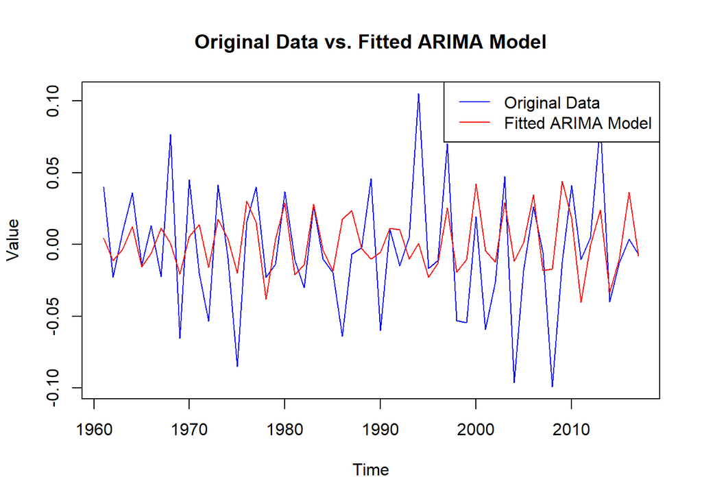

```r
# Plot the original data and the fitted values from the automatically selected ARIMA model
plot(exports_diff, type = "l", col = "blue", xlab = "Time", ylab = "Value", main = "Original Data vs. Fitted ARIMA Model")
lines(fitted(auto_arima_model), col = "red")

# Add a legend
legend("topright", legend = c("Original Data", "Fitted ARIMA Model"), col = c("blue", "red"), lty = 1)
```

```r
# Compute AIC and BIC values for each model
aic_values <- c(AIC(arima(exports,order=c(2,1,0))), AIC(arima(exports,order=c(2,1,3))), AIC(arima(exports,order=c(0,1,3))), AIC(arima(exports,order=c(0,1,2))),AIC(Arima(exports,order=c(2,1,0),include.drift=TRUE)),AIC(Arima(exports,order=c(2,1,3),include.drift=TRUE)),AIC(Arima(exports,order=c(0,1,3),include.drift=TRUE)),AIC(Arima(exports,order=c(0,1,2),include.drift=TRUE)))
bic_values <- c(BIC(arima(exports,order=c(2,1,0))), BIC(arima(exports,order=c(2,1,3))), BIC(arima(exports,order=c(0,1,3))), BIC(arima(exports,order=c(0,1,2))),BIC(Arima(exports,order=c(2,1,0),include.drift=TRUE)),BIC(Arima(exports,order=c(2,1,3),include.drift=TRUE)),BIC(Arima(exports,order=c(0,1,3),include.drift=TRUE)),BIC(Arima(exports,order=c(0,1,2),include.drift=TRUE)))

# Create a data frame to organize the results
results <- data.frame(Model = c("ARMA(2,1,0)", "ARMA(2,1,3)", "ARMA(0,1,3)","ARMA(0,1,2)","ARMA(2,1,0) Drift", "ARMA(2,1,3) Drift", "ARMA(0,1,3) Drift","ARMA(0,1,2) Drift"), AIC = aic_values, BIC = bic_values)

# Calculate the absolute difference between AIC and BIC
results$Abs_Diff <- abs(results$AIC - results$BIC)
results
```

| Model | AIC | BIC | Abs_Diff |
| --- | --- | --- | --- |
| ARMA(2,1,0) | 274.5368 | 280.6660 | 6.129154 |
| ARMA(2,1,3) | 273.9831 | 286.2414 | 12.258308 |
| ARMA(0,1,3) | 274.2477 | 282.4199 | 8.172205 |
| ARMA(0,1,2) | 275.6966 | 281.8257 | 6.129154 |
| ARMA(2,1,0) Drift | 275.2535 | 283.4257 | 8.172205 |
| ARMA(2,1,3) Drift | 274.9422 | 289.2436 | 14.301359 |
| ARMA(0,1,3) Drift | 275.7967 | 286.0120 | 10.215256 |
| ARMA(0,1,2) Drift | 276.9275 | 285.0997 | 8.172205 |

```r
log.exports=log(exports)
log.exports
```

```
## Time Series:
## Start = 1960
## End = 2017
## Frequency = 1
##  [1] 3.147282 3.276770 3.202347 3.228295 3.348087 3.299544 3.344645 3.269673
##  [9] 3.535504 3.308156 3.463812 3.394483 3.216264 3.354037 3.322761 3.050710
## [17] 3.099501 3.227018 3.153604 3.110514 3.227699 3.193905 3.099090 3.184243
## [25] 3.152479 3.091430 2.900676 2.881675 2.876090 3.010812 2.837174 2.867141
## [33] 2.825282 2.839052 3.152711 3.101035 3.066675 3.291542 3.120464 2.956141
## [41] 3.014172 2.842421 2.770255 2.903398 2.638909 2.592471 2.661378 2.647261
## [49] 2.398228 2.368786 2.468714 2.443636 2.455234 2.670797 2.567261 2.534643
## [57] 2.543886 2.527175
```

```r
# Finds the coefficients/log likelihood
log.export.ma1=Arima(exports,order=c(2,1,0),include.drift=TRUE)
ma1.res=log.export.ma1$residuals
log.export.ma1
```

```
## Series: exports
## ARIMA(2,1,0) with drift
##
## Coefficients:
##           ar1      ar2    drift
##       -0.5230  -0.3065  -0.2120
## s.e.   0.1262   0.1248   0.1841
##
## sigma^2 = 6.675:  log likelihood = -133.63
## AIC=275.25   AICc=276.02   BIC=283.43
```